# R Notebook

## Build the decision tree using the Gini Index

```r
# Build the decision tree using the Gini index
decision_tree <- rpart(Dataset ~ ., data = combined_train, method = "class")
```

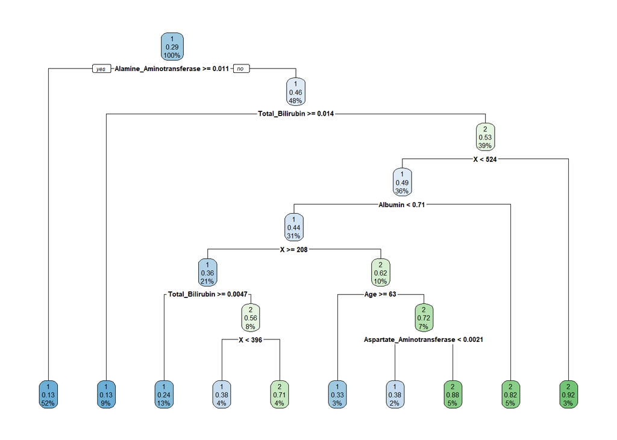

```r
# Plot the decision tree
rpart.plot(decision_tree)
```

the root node of interest in this data is “Alamine_Aminotransferase.” This means that the decision tree starts by splitting the data based on the value of the “Alamine_Aminotransferase” feature.

The decision tree then branches out to other internal nodes, such as “Age,” ,“Albumin” and “Total_Bilirubin.”

### Make predictions on the testing set

```r
predictions <- predict(decision_tree, newdata = combined_test, type = "class")
```

```r
table(predictions, combined_test$Dataset)
```

```
##
## predictions   1   2
##           1 151  54
##           2  16  13
```

```r
predictions <- factor(predictions, levels = c("1", "2"))
combined_test$Dataset <- factor(combined_test$Dataset, levels = c("1", "2"))

confusionMatrix(predictions, combined_test$Dataset)
```

```
## Confusion Matrix and Statistics
##
##           Reference
## Prediction   1   2
##          1 151  54
##          2  16  13
##
##                Accuracy : 0.7009
##                  95% CI : (0.6378, 0.7588)
##     No Information Rate : 0.7137
##     P-Value [Acc > NIR] : 0.6963
##
##                   Kappa : 0.1183
##
##  Mcnemar's Test P-Value : 9.764e-06
##
##             Sensitivity : 0.9042
##             Specificity : 0.1940
##          Pos Pred Value : 0.7366
##          Neg Pred Value : 0.4483
##              Prevalence : 0.7137
##          Detection Rate : 0.6453
##    Detection Prevalence : 0.8761
##       Balanced Accuracy : 0.5491
##
##        'Positive' Class : 1
##
```

Accuracy (0.7009): The model’s predictions are correct approximately 70.09% of the time.

Precision (0.7366): About 73.66% of the instances predicted as positive are actually positive.

Sensitivity (0.9042): The model correctly identifies about 90.42% of the actual positive instances.

Specificity (0.1940): The model correctly identifies only about 19.40% of the actual negative instances.

the model demonstrates a high sensitivity, indicating its effectiveness in detecting positive instances. However, it has limitations in accurately identifying negative instances, as shown by the low specificity. The precision indicates that the model is reasonably good at predicting positive instances, with a precision of 73.66%.

## What is the best tree for this size?

decision tree using information gain provides a better balance between sensitivity and specificity.

# size for training 80%

tree of information gain:

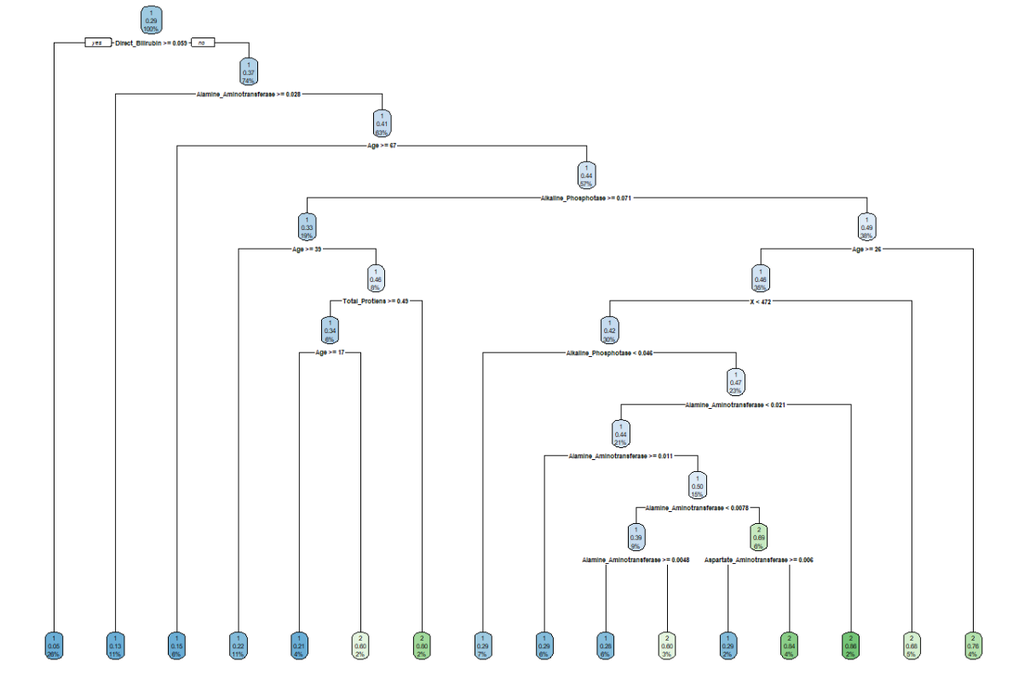

tree of gain ratio: best tree

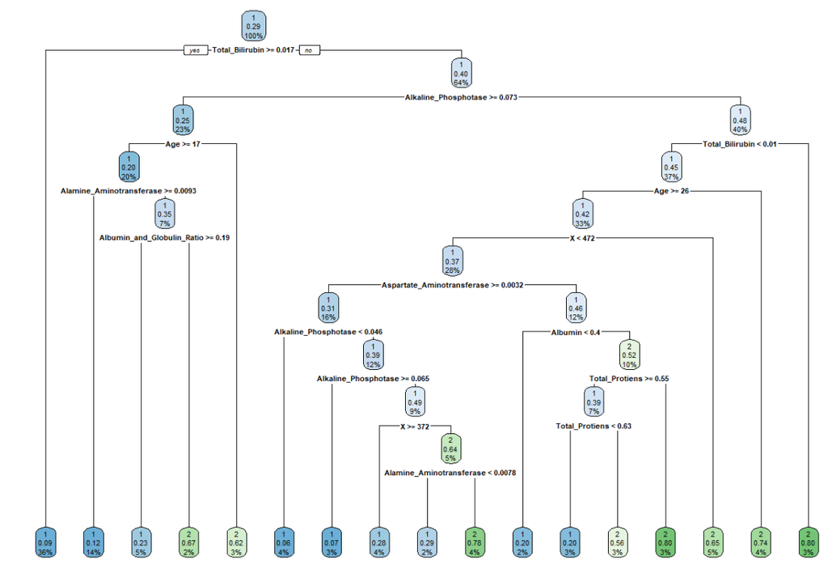

tree of gini index: (best tree)

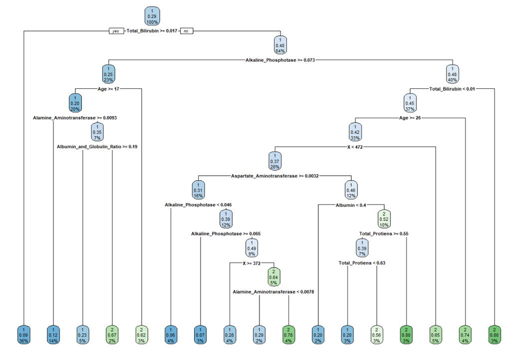

```r
# Set the seed for reproducibility
set.seed(123)
```

## Split the dataset into training and testing sets

```r
# Subset the first dataset
df1 <- prdataset[which(prdataset$Dataset == 1),]

# Subset the second dataset
df2 <- prdataset[which(prdataset$Dataset == 2),]

# Splitting the first dataset
n1 <- nrow(df1)  # Total number of rows in df1
train_indices1 <- sample(1:n1, 0.8 * n1, replace = FALSE)  # Randomly select 70% of indices for training
test_indices1 <- setdiff(1:n1, train_indices1)  # Remaining indices for testing

# Splitting the second dataset
n2 <- nrow(df2)  # Total number of rows in df2
train_indices2 <- sample(1:n2, 0.8 * n2, replace = FALSE)  # Randomly select 70% of indices for training
test_indices2 <- setdiff(1:n2, train_indices2)  # Remaining indices for testing

# Creating the training and testing sets
train_df1 <- df1[train_indices1, ]
test_df1 <- df1[test_indices1, ]
train_df2 <- df2[train_indices2, ]
test_df2 <- df2[test_indices2, ]

# Combining the 80% training sets
combined_train <- rbind(train_df1, train_df2)

# Combining the 20% testing sets
combined_test <- rbind(test_df1, test_df2)
```

## Build the decision tree using information gain

```r
decision_tree <- rpart(Dataset ~ ., data = combined_train, method = "class", parms = list(split = "information"))
```

### Plot the decision tree

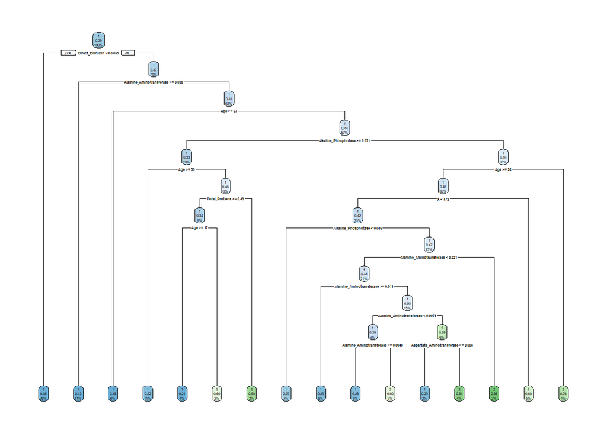

```r
rpart.plot(decision_tree)
```

the root node of interest in this data is “Direct_Bilirubin.” This means that the decision tree starts by splitting the data based on the value of the “Direct_Bilirubin” feature.

The decision tree then branches out to other internal nodes, such as “Alamine_Aminotransferase,” “Age,” “Alkaline_Phosphotase,” “Total_Protiens,” and “Aspartate_Aminotransferase.”

### Make predictions on the testing set

```r
predictions <- predict(decision_tree, newdata = combined_test, type = "class")
```

```r
table(predictions, combined_test$Dataset)
```

```
##
## predictions  1  2
##           1 66 19
##           2 18 15
```

```r
predictions <- factor(predictions, levels = c("1", "2"))
combined_test$Dataset <- factor(combined_test$Dataset, levels = c("1", "2"))

confusionMatrix(predictions, combined_test$Dataset)
```

```
## Confusion Matrix and Statistics
##
##           Reference
## Prediction  1  2
##          1 66 19
##          2 18 15
##
##                Accuracy : 0.6864
##                  95% CI : (0.5946, 0.7687)
##     No Information Rate : 0.7119
##     P-Value [Acc > NIR] : 0.7637
##
##                   Kappa : 0.2289
##
##  Mcnemar's Test P-Value : 1.0000
##
##             Sensitivity : 0.7857
##             Specificity : 0.4412
##          Pos Pred Value : 0.7765
##          Neg Pred Value : 0.4545
##              Prevalence : 0.7119
##          Detection Rate : 0.5593
##    Detection Prevalence : 0.7203
##       Balanced Accuracy : 0.6134
##
##        'Positive' Class : 1
##
```

Accuracy (0.6864): The model’s predictions are correct approximately 68.64% of the time.

Precision (0.7765): About 77.65% of the instances predicted as positive are actually positive.

Sensitivity (0.7857): The model correctly identifies about 78.57% of the actual positive instances.

Specificity (0.4412): The model correctly identifies about 44.12% of the actual negative instances.

the model demonstrates a relatively high sensitivity, indicating its effectiveness in detecting positive instances. However, it has limitations in accurately identifying negative instances, as shown by the low specificity. The precision indicates that the model is reasonably good at predicting positive instances, with a precision of 77.65%.

## Build the decision tree using gain ratio

```r
decision_tree <- rpart(Dataset ~ ., data = combined_train, method = "class", parms = list(split = "gain"))
```

### Plot the decision tree

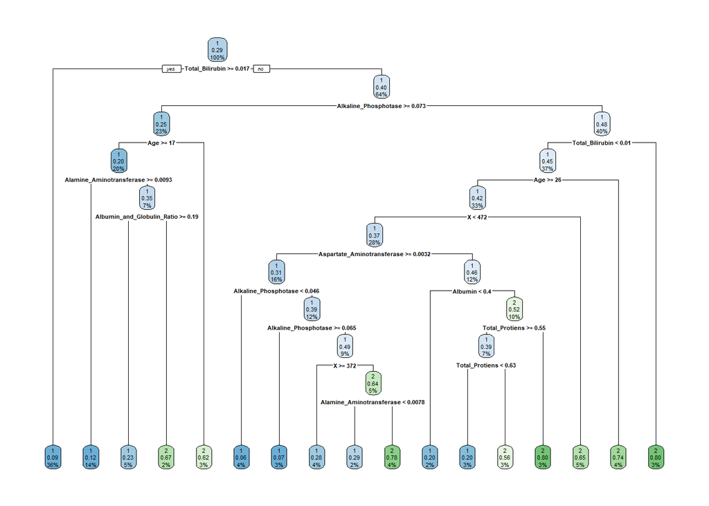

```r
rpart.plot(decision_tree)
```

the root node of interest in this data is “Total_Bilirubin.” This means that the decision tree starts by splitting the data based on the value of the “Total_Bilirubin” feature.

The decision tree then branches out to other internal nodes, such as “Age,” “Alamine_Aminotransferase,” “Albumin,” “Alkaline_Phosphotase,”

### Make predictions on the testing set

```r
predictions <- predict(decision_tree, newdata = combined_test, type = "class")
```

```r
table(predictions, combined_test$Dataset)
```

```
##
## predictions  1  2
##           1 63 16
##           2 21 18
```

```r
predictions <- factor(predictions, levels = c("1", "2"))
combined_test$Dataset <- factor(combined_test$Dataset, levels = c("1", "2"))

confusionMatrix(predictions, combined_test$Dataset)
```

```
## Confusion Matrix and Statistics
##
##           Reference
## Prediction  1  2
##          1 63 16
##          2 21 18
##
##                Accuracy : 0.6864
##                  95% CI : (0.5946, 0.7687)
##     No Information Rate : 0.7119
##     P-Value [Acc > NIR] : 0.7637
##
##                   Kappa : 0.2677
##
##  Mcnemar's Test P-Value : 0.5108
##
##             Sensitivity : 0.7500
##             Specificity : 0.5294
##          Pos Pred Value : 0.7975
##          Neg Pred Value : 0.4615
##              Prevalence : 0.7119
##          Detection Rate : 0.5339
##    Detection Prevalence : 0.6695
##       Balanced Accuracy : 0.6397
##
##        'Positive' Class : 1
##
```

Accuracy (0.6864): The model’s predictions are correct approximately 68.64% of the time.

Precision (0.7975): About 79.75% of the instances predicted as positive are actually positive.

Sensitivity (0.7500): The model correctly identifies about 75.00% of the actual positive instances.

Specificity (0.5294): The model correctly identifies about 52.94% of the actual negative instances.

the model demonstrates a relatively high sensitivity, indicating its effectiveness in detecting positive instances. However, it has limitations in accurately identifying negative instances, as shown by the moderate specificity. The precision indicates that the model is reasonably good at predicting positive instances, with a precision of 79.75%.

## Build the decision tree using the Gini index

```r
decision_tree <- rpart(Dataset ~ ., data = combined_train, method = "class")
```

### Plot the decision tree

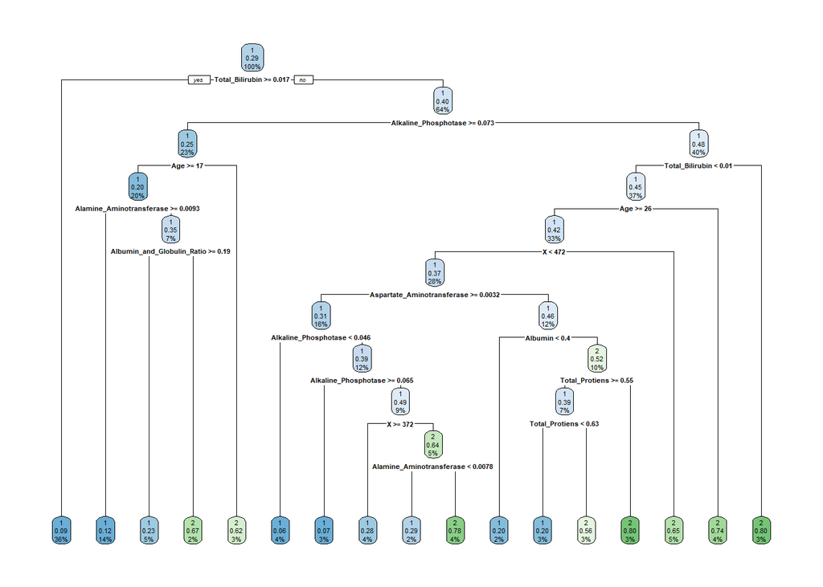

```r
rpart.plot(decision_tree)
```

the root node of interest in this data is “Total_Bilirubin.” This means that the decision tree starts by splitting the data based on the value of the “Total_Bilirubin” feature.

The decision tree then branches out to other internal nodes, such as “Age,” “Alamine_Aminotransferase,” “Albumin,” “Alkaline_Phosphotase,”

### Make predictions on the testing set

```r
predictions <- predict(decision_tree, newdata = combined_test, type = "class")
```

```r
table(predictions, combined_test$Dataset)
```

```
##
## predictions  1  2
##           1 63 16
##           2 21 18
```

```r
predictions <- factor(predictions, levels = c("1", "2"))
combined_test$Dataset <- factor(combined_test$Dataset, levels = c("1", "2"))

confusionMatrix(predictions, combined_test$Dataset)
```

```
## Confusion Matrix and Statistics
##
##           Reference
## Prediction  1  2
##          1 63 16
##          2 21 18
##
##                Accuracy : 0.6864
##                  95% CI : (0.5946, 0.7687)
##     No Information Rate : 0.7119
##     P-Value [Acc > NIR] : 0.7637
##
##                   Kappa : 0.2677
##
##  Mcnemar's Test P-Value : 0.5108
##
##             Sensitivity : 0.7500
##             Specificity : 0.5294
##          Pos Pred Value : 0.7975
##          Neg Pred Value : 0.4615
##              Prevalence : 0.7119
##          Detection Rate : 0.5339
##    Detection Prevalence : 0.6695
##       Balanced Accuracy : 0.6397
##
##        'Positive' Class : 1
##
```

Accuracy (0.6864): The model’s predictions are correct approximately 68.64% of the time.

Precision (0.7975): About 79.75% of the instances predicted as positive are actually positive.

Sensitivity (0.7500): The model correctly identifies about 75.00% of the actual positive instances.

Specificity (0.5294): The model correctly identifies about 52.94% of the actual negative instances.

the model demonstrates a relatively high sensitivity, indicating its effectiveness in detecting positive instances. However, it has limitations in accurately identifying negative instances, as shown by the moderate specificity. The precision indicates that the model is reasonably good at predicting positive instances, with a precision of 79.75%.

## What is the best tree for this size?

Both trees have similar accuracy and sensitivity values. However, the decision tree using Gini index-based tree has a higher specificity (0.5294) compared to the information gain-based tree (specificity: 0.4412).

Considering the specificity values, the decision tree using Gini index and gain ratio performs slightly better in terms of correctly identifying negative instances. However, the differences in performance are relatively small.

# clustring

our goal of clustering is to enhance our understanding of liver disease by grouping patients with similar attributes and to uncover hidden patterns or groupings within the patient data that may not be immediately apparent to us.

This Function to calculate BCubed Precision and BCubed Recall, that will be called in k= 2,3,4.

```r
#--define function --
# Function to calculate BCubed Precision
calculate_bcubed_precision <- function(data) {
  precision_values <- numeric(nrow(data))

  for (i in 1:nrow(data)) {
    # Get all points in the same cluster
    same_cluster <- data$Cluster[i] == data$Cluster

    # Get all points with the same external label
    same_label <- data$Label[i] == data$Label

    # Calculate precision for this point
    precision_values[i] <- sum(same_cluster & same_label) / sum(same_cluster)
  }


  mean(precision_values)
}

# Function to calculate BCubed Recall
calculate_bcubed_recall <- function(data) {
  recall_values <- numeric(nrow(data))

  for (i in 1:nrow(data)) {
    # Get all points with the same external label
    same_label <- data$Label[i] == data$Label

    # Get all points in the same cluster as the current point
    same_cluster <- data$Cluster[i] == data$Cluster

    # Calculate recall for this point
    recall_values[i] <- sum(same_cluster & same_label) / sum(same_label)
  }


  mean(recall_values)
}
```

Since clustering is an unsupervised learning method, we should omit the class labels.

```r
external_labels <- prdataset$Dataset
prdataset =subset (prdataset, select = -c(Dataset))
```

## Find optimal number of clusters

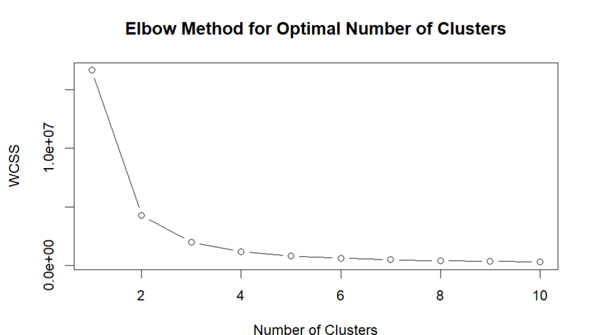

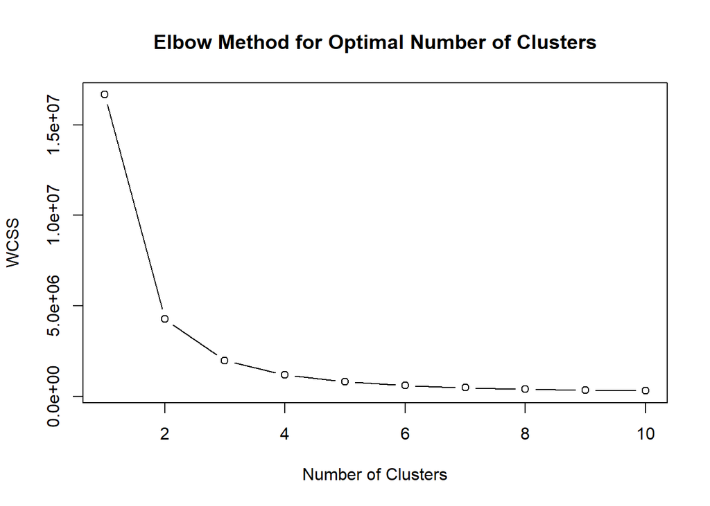

```r
set.seed(123)  # Set seed for reproducibility
wss <- numeric(10)

  for (k in 1:10) {
  # Run the k-means algorithm on the dataset
  M <- kmeans(prdataset, centers = k, nstart = 25)
  # Store the within-cluster sum of squares
  wss[k] <- M$tot.withinss
    }

# We use the elbow method to find the optimal number of clusters.
plot(1:10, wss, type = "b", xlab = "Number of Clusters", ylab = "WCSS",
     main = "Elbow Method for Optimal Number of Clusters")
```

The optimal number of clusters according to the elbow method is found at the point where the within-cluster sum of squares (WCGSS) starts to decrease at a slower rate. the “elbow” appears to be at the point corresponding to 2 clusters, so we decide to choose sizes of clusters to be close from each other which is: k=2,3,4 to give us the best results.

Here in the cluster 2(k=2) we will visualize it and caluclate the Average Silhouette width, total within-cluster sum of square, bcubed_precision, bcubed_recall. reason of why we choose k=2? starting with two clusters can provide a baseline for comparison. If the results are not satisfactory, we can increase the k. Also in a medical dataset, patients might naturally fall into ‘disease’ and ‘no disease’ categories.

```r
k <- 2
set.seed(8953)
prdataset=scale(prdataset)
kmeans.result <- kmeans(prdataset, 2)
# clusterng result
kmeans.result
```

```
## K-means clustering with 2 clusters of sizes 264, 319
##
## Cluster means:
##             X        Age     Gender Total_Bilirubin Direct_Bilirubin
## 1 -0.11981473  0.3226442 -0.1966391       0.3717513        0.3941878
## 2  0.09915702 -0.2670159  0.1627358      -0.3076562       -0.3262244
##   Alkaline_Phosphotase Alamine_Aminotransferase Aspartate_Aminotransferase
## 1            0.2730908                0.1979314                  0.2076257
## 2           -0.2260062               -0.1638053                 -0.1718282
##   Total_Protiens    Albumin Albumin_and_Globulin_Ratio
## 1     -0.6252190 -0.8301665                 -0.6443109
## 2      0.5174227  0.6870344                  0.5332228
##
## Clustering vector:
##   1   2   3   4   5   6   7   8   9  10  11  12  13  14  15  16  17  18  19  20
```

[output cut: 68 more lines]

plot of k = 2:

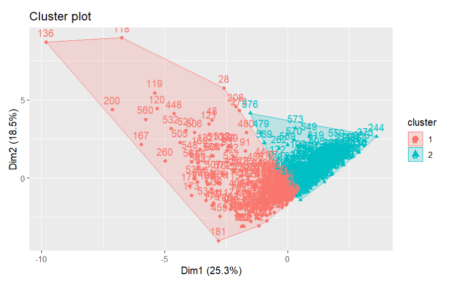

Evaluation metrics for k=2:

```r
#-----Average Silhouette width ----
library(fpc)
cluster_assignments <- kmeans.result$cluster
diss_matrix <- dist(prdataset)
silhouette_avg <- cluster.stats(diss_matrix, cluster_assignments)$avg.silwidth
cat("Average Silhouette Width:", silhouette_avg, "\n")
```

```
## Average Silhouette Width: 0.1835652
```

```r
#-----calculate total within-cluster sum of square----
total_wss_k2 <- kmeans.result$tot.withinss
print(paste("Total within-cluster sum of squares for k=2: ", total_wss_k2))
```

```
## [1] "Total within-cluster sum of squares for k=2:  5387.44462577426"
```

```r
#-----calculate bcubed---
combined_data <- data.frame(Cluster = kmeans.result$cluster, Label = external_labels)
bcubed_precision <- calculate_bcubed_precision(combined_data)
bcubed_recall <- calculate_bcubed_recall(combined_data)

print(paste("BCubed Precision for k =", k, ":", bcubed_precision))
```

```
## [1] "BCubed Precision for k = 2 : 0.612047009397219"
```

```r
print(paste("BCubed Recall for k =", k, ":", bcubed_recall))
```

```
## [1] "BCubed Recall for k = 2 : 0.529711983869706"
```

result of Evaluation metrics for k=2:

Average Silhouette Width: The silhouette width measures how similar an object is to its own cluster compared to other clusters. Total within-cluster sum of squares: This metric represents the total variance within each cluster. Lower values indicate that points within each cluster are closer to each other. Precision: measures the extent to which members of the same cluster are similar. recall: assesses how well the algorithm groups similar items into the same cluster.

-Average Silhouette Width (0.1835652): The clusters have some overlap, and the distinction between them is moderate. -Total Within-Cluster Sum of Squares A value of 5387.44462577426 suggests there’s a fair amount of variation within the clusters. -Precision (0.612) A score of 0.612 means about 61% of the points in each cluster are correctly placed. -Recall (0.529) A score of 0.529 means the algorithm correctly groups about 53% of similar points together.

visualize clustering for k=2:

```r
library(factoextra)
```

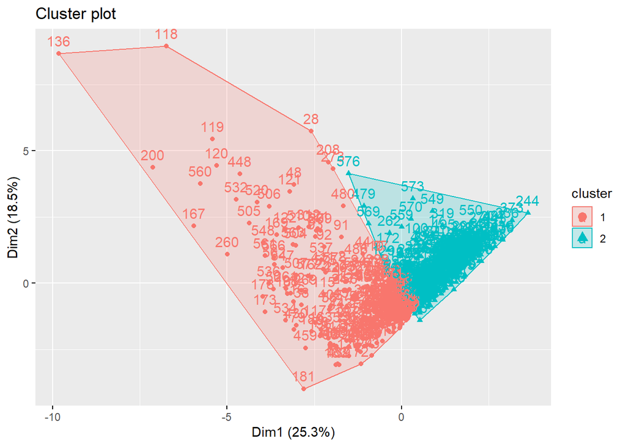

```r
fviz_cluster(kmeans.result, data = prdataset)
```

result of plot: Blue Cluster: This cluster’s core is tightly packed the points are closely grouped, indicating strong similarity among the data points. Red Cluster: The core of this cluster is more spread out. This spread suggests a wider variance in the characteristics of these data points.There is a slight overlap between the clusters around the center.

here in the cluster 3 (k=3) we will visualize it and caluclate the Average Silhouette width, total within-cluster sum of square, bcubed_precision, bcubed_recall. reason of why we choose k=3? it provide more details. Three clusters allow for more granularity than two, offering a more nuanced view of the data, which can be crucial for decision-making.

```r
k <- 3
set.seed(8953)
prdataset=scale(prdataset)
kmeans.result <- kmeans(prdataset, 3)
# clusterng result
kmeans.result
```

```
## K-means clustering with 3 clusters of sizes 274, 260, 49
##
## Cluster means:
##            X         Age     Gender Total_Bilirubin Direct_Bilirubin
## 1 -0.2030851  0.38087286 -0.1336963      -0.1358703       -0.1300708
## 2  0.1538079 -0.38414340  0.1940286      -0.3281485       -0.3472807
## 3  0.3194949 -0.09146694 -0.2819316       2.5009611        2.5700486
##   Alkaline_Phosphotase Alamine_Aminotransferase Aspartate_Aminotransferase
## 1            0.1777674               -0.1408433                 -0.1061416
## 2           -0.2662415               -0.1760593                 -0.1781286
## 3            0.4186640                1.7217648                  1.5386988
##   Total_Protiens    Albumin Albumin_and_Globulin_Ratio
## 1    -0.63747623 -0.7215031                 -0.5030709
## 2     0.65648152  0.8500420                  0.6250310
## 3     0.08129168 -0.4758997                 -0.5034011
```

[output cut: 71 more lines]

plot of k =3:

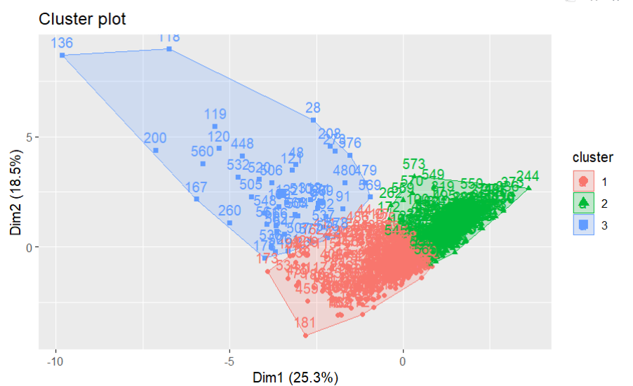

Evaluation metrics for k=3:

```r
#-----Average Silhouette width ----
library(fpc)
cluster_assignments <- kmeans.result$cluster
diss_matrix <- dist(prdataset)
silhouette_avg <- cluster.stats(diss_matrix, cluster_assignments)$avg.silwidth
cat("Average Silhouette Width:", silhouette_avg, "\n")
```

```
## Average Silhouette Width: 0.1826926
```

```r
#-----calculate total within-cluster sum of square----
total_wss_k3 <- kmeans.result$tot.withinss
print(paste("Total within-cluster sum of squares for k=3: ", total_wss_k3))
```

```
## [1] "Total within-cluster sum of squares for k=3:  4512.8178013199"
```

```r
#-----calculate bcubed---
combined_data <- data.frame(Cluster = kmeans.result$cluster, Label = external_labels)
bcubed_precision <- calculate_bcubed_precision(combined_data)
bcubed_recall <- calculate_bcubed_recall(combined_data)

print(paste("BCubed Precision for k =", k, ":", bcubed_precision))
```

```
## [1] "BCubed Precision for k = 3 : 0.617273045092905"
```

```r
print(paste("BCubed Recall for k =", k, ":", bcubed_recall))
```

```
## [1] "BCubed Recall for k = 3 : 0.443194607618119"
```

visualize clustering for k=3:

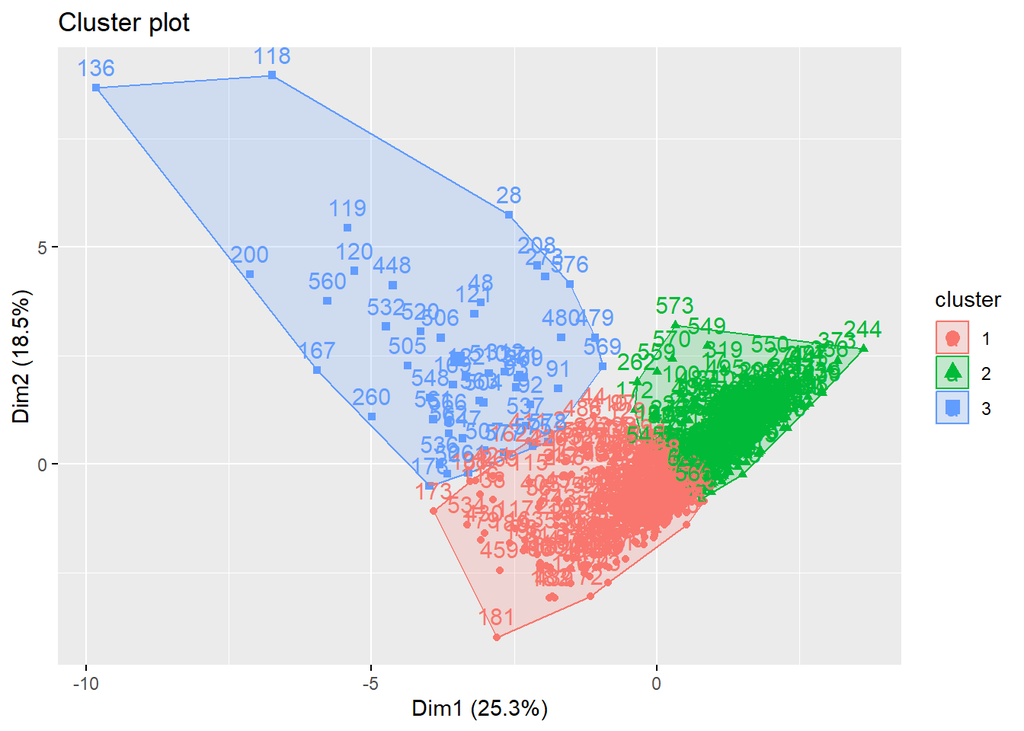

```r
library(factoextra)
fviz_cluster(kmeans.result, data = prdataset)
```

result of plot: Red Group: These points are close but a bit more spread out than the green, showing more diversity. Green Group: Tight bunch of points.They are very similar to each other. Blue Group: This group is the most spread out, indicating the most diverse characteristics among its points. Overlapping: Some points from the red and green groups are mixed together in the middle. The red and blue groups also have some mixing at their edges. This means some data points could belong to more than one group.

here in the cluster 4 (k=4) we will visualize it and caluclate the Average Silhouette width, total within-cluster sum of square, bcubed_precision, bcubed_recall. reason of why we choose k=4? it provide more details. Three clusters allow for more granularity than two, offering a more nuanced view of the data, which can be crucial for decision-making.

```r
k <- 4
set.seed(8953)
prdataset=scale(prdataset)
kmeans.result <- kmeans(prdataset, 4)
# clustering result
kmeans.result
```

```
## K-means clustering with 4 clusters of sizes 172, 156, 44, 211
##
## Cluster means:
##             X         Age        Gender Total_Bilirubin Direct_Bilirubin
## 1 -0.96527671  0.33313464 -6.622730e-02     -0.09278088      -0.08096336
## 2  0.86581641  0.23226117  5.118812e-05     -0.23053170      -0.24224237
## 3  0.44336847 -0.09662375 -2.495421e-01      2.72548011       2.79275263
## 4  0.05427498 -0.42313012  1.059856e-01     -0.32227425      -0.33727776
##   Alkaline_Phosphotase Alamine_Aminotransferase Aspartate_Aminotransferase
## 1            0.3863286              -0.04405284                -0.01709782
## 2           -0.1816415              -0.18313577                -0.15992632
## 3            0.4510730               1.64232958                 1.50521550
## 4           -0.2746904              -0.17116698                -0.18170688
##   Total_Protiens    Albumin Albumin_and_Globulin_Ratio
## 1     -0.6835048 -0.6745534                 -0.4082647
```

[output cut: 74 more lines]

plot of k =4

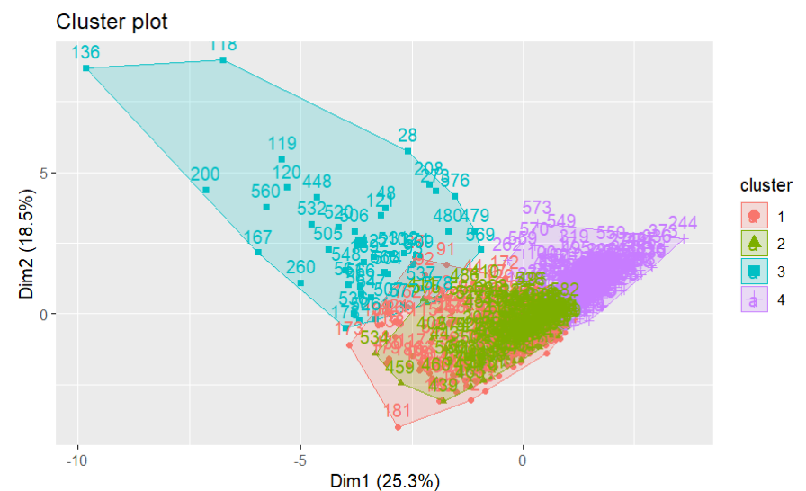

Evaluation metrics for k=4:

```r
#-----Average Silhouette width ----
library(fpc)
cluster_assignments <- kmeans.result$cluster
diss_matrix <- dist(prdataset)
silhouette_avg <- cluster.stats(diss_matrix, cluster_assignments)$avg.silwidth
cat("Average Silhouette Width:", silhouette_avg, "\n")
```

```
## Average Silhouette Width: 0.1457903
```

```r
#-----calculate total within-cluster sum of square----
total_wss_k4 <- kmeans.result$tot.withinss
print(paste("Total within-cluster sum of squares for k=4: ", total_wss_k4))
```

```
## [1] "Total within-cluster sum of squares for k=4:  4226.49707113082"
```

```r
#-----calculate bcubed---
combined_data <- data.frame(Cluster = kmeans.result$cluster, Label = external_labels)
bcubed_precision <- calculate_bcubed_precision(combined_data)
bcubed_recall <- calculate_bcubed_recall(combined_data)

print(paste("BCubed Precision for k =", k, ":", bcubed_precision))
```

```
## [1] "BCubed Precision for k = 4 : 0.615271780618268"
```

```r
print(paste("BCubed Recall for k =", k, ":", bcubed_recall))
```

```
## [1] "BCubed Recall for k = 4 : 0.307632064015524"
```

result of Evaluation metrics for k=4: Average Silhouette Width a score of 0.1457903 is quite low, suggesting that there’s considerable overlap between clusters. Total within-cluster sum of squares the value of 4226.49707113082 indicates the extent of variance within the clusters. A precision of 0.615 means about 61.5% of pairs of points within the same cluster are correctly classified. A recall of 0.307 is quite low indicating that many similar points are not being grouped together.

visualize clustering for k=4:

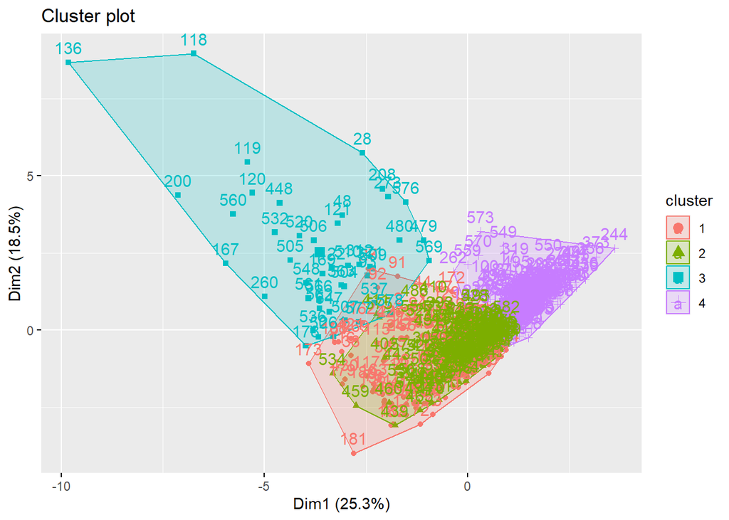

```r
library(factoextra)
fviz_cluster(kmeans.result, data = prdataset)
```

result of plot:

Cluster (Purple): The points here are closely grouped, which implies that the data points within this cluster have similar characteristics and there’s a strong cohesion among them. Cluster (Green): The points are also relatively close to each other. Cluster (Blue): The points here are widely dispersed, suggesting a high degree of variability among the data points in this cluster. Cluster (red): This cluster has data points that are spread out across a wide area, indicating significant diversity within the cluster. Overlap Areas: There are areas where the clusters seem to blend into each other, particularly between clusters (green) and (red), and to a lesser extent between clusters (purple) and (green). This overlap implies that some data points share characteristics with more than one cluster and to a lesser extent between clusters (blue) and (red).

## Evaluation and Comparison

for Classification:

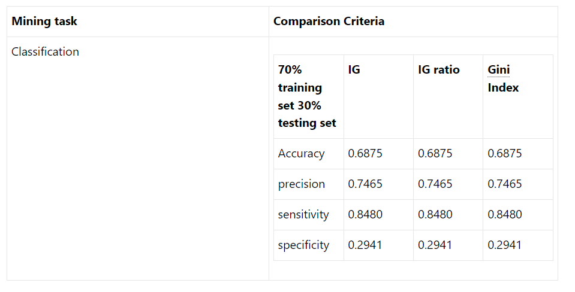

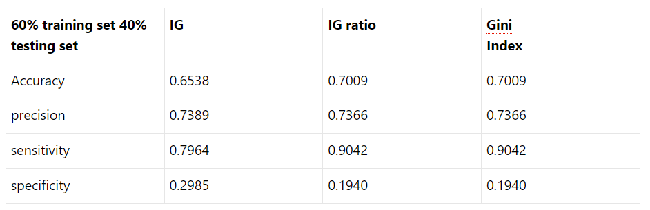

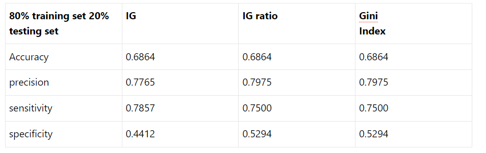

What is the best size for training data?

1. Training Size: 70% (Information Gain)
   - Accuracy: 0.6875
   - Precision: 0.7465
   - Sensitivity: 0.8480
   - Specificity: 0.2941
2. Training Size: 60% (Information Gain)
   - Accuracy: 0.6538
   - Precision: 0.7389
   - Sensitivity: 0.7964
   - Specificity: 0.2985
3. Training Size: 80% (Gini Index and Gain Ratio)
   - Accuracy: 0.6864
   - Precision: 0.7975
   - Sensitivity: 0.7500
   - Specificity: 0.5294

Based on the specificity metric, the third model with a training size of 80% and using either the Gini index or gain ratio for splitting seems to perform the best. It has the highest specificity value (0.5294), indicating that it correctly identifies about 52.94% of the actual negative instances.

for Clustering:

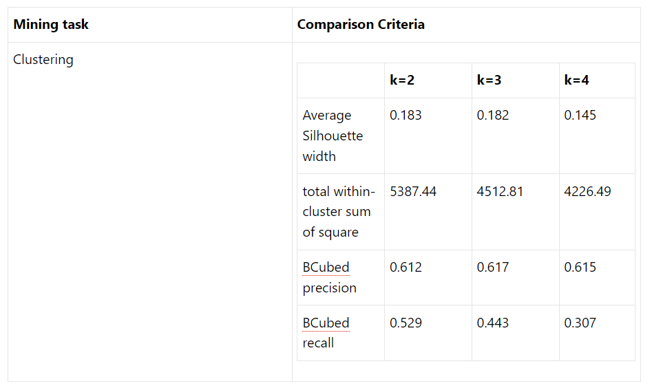

In summary here is the results of Evaluation metrics of k=2,3,4:

For ( k = 2 ):

- Average Silhouette Width: 0.183  
- Total Within-Cluster Sum of Squares (WSS): 5387.44  
- BCubed Precision: 0.612  
- BCubed Recall: 0.529  
For ( k = 3 ):  
- Average Silhouette Width: 0.182  
- Total WSS: 4512.81  
- BCubed Precision: 0.617  
- BCubed Recall: 0.443  
For ( k = 4 ):  
- Average Silhouette Width: 0.145  
- Total WSS: 4226.49  
- BCubed Precision: 0.615  
- BCubed Recall: 0.307  
Now, let’s analyze the comparisons:  
1. **Total Within-Cluster Sum of Squares (WSS)**:  
- ( k = 2 ) has the highest WSS (5387.44), indicating less compact clusters and broader groupings.  
- ( k = 3 ) has a significant reduction in WSS compared to ( k = 2 ), indicating tighter and more compact clusters.  
- ( k = 4 ) further reduces WSS, but the decrease is less pronounced compared to( k = 3 ).  
2. **Average Silhouette Width**:  
in k=2, k=3 suggests that while two clusters exhibit a relatively stronger separation, the scenario with four clusters shows a lower separation between clusters.  
3. **BCubed Precision and Recall**:  
- ( k = 2 ) has the highest BCubed recall (0.529), indicating better grouping of similar items together.  
- ( k = 3 ) has the highest BCubed precision (0.617), suggesting purer clusters.  
- ( k = 4 ) has the lowest BCubed recall (0.307), implying potential splitting of similar items into different clusters.

The optimal number of clusters for the data presented appears to be 2, because it has a higher Recall and Average Silhouette Width among the clusters, and we think it is the best because our data set about healthcare, thus, objects are collected based on whether they diseases or no diseases.

# Findings:

At the outset, we curated a comprehensive dataset comprising liver patient records. Our primary objective was to predict the likelihood of liver disease among individuals. This predictive analysis aims to empower patients with the necessary insights, enabling them to take proactive measures for better health outcomes and improved quality of life.

To get the best results, we used different ways to clean up and understand our data better. We looked at graphs like boxplots and histograms to spot any missing or outliers’ points. After that, we fixed these issues by removing them or changing some data to make everything fair. These steps were crucial to standardize attributes and ensure uniformity. This made it easier to handle the data when we were looking for useful patterns.

As a result, we dove into data mining techniques like classification and clustering. For our classification tasks, we specifically employed the decision tree method to build our models. Experimenting with varying sizes of training and testing data (three different sizes), we aimed to determine the optimal setup for constructing and evaluating our models. Here are the key findings from our exploration:

Based on the results from Confusion Matrix and Statistics, the best tree would be of 80% training data and using either the Gini index or gain ratio for splitting , based on It has the highest specificity value wich is 0.5294.

this tree illustrate the root node of interest in this data is “Total_Bilirubin.” This means that the decision tree starts by splitting the data based on the value of the “Total_Bilirubin” feature.

In the context of Clustering, we employed the K-means algorithm, exploring three different values for K to determine the optimal number of clusters.

our goal is to distinguish between diseased and non-diseased groups for practical decision-making, so we think that having two distinct clusters might be more practically valuable.

In the end for classifying patients into diseased and non-diseased groups, clustering might not be the best approach because clustering is an unsupervised learning technique and doesn’t take into account the labeled data (diseased or non-diseased in this case).

for classification tasks where the goal is to assign new data points to predefined classes, supervised learning algorithms like classification models are typically more suitable in our sitution.